# Syntyvyyden lasku ja sen mahdolliset selitykset

Antti J. Tanskanen, Elinkeinoelämän keskusliitto EK

16.5.2018

## Johdanto

Syntyneiden lasten määrä on Suomessa laskenut 61 000 lapsesta vuonna 2010 noin 50 300:ään vuonna 2017. Laskeva trendi on jatkunut koko aikavälin 2010-2017, joten satunnaisvaihtelusta tuskin on kysymys. Osan laskusta selittää synnytysikäisten naisten lukumäärän pieneneminen, mutta ei läheskään kaikkea. Muiksi selityksiksi on tarjottu mm. työttömyyttä (Hiilamo, 2017) ja miesten heikkoa työsuhteeseen kiinnittymistä (Miettinen ja Jalovaara, 2015). Muissa maissa syntyvyyden laskun on arvioitu aiheutuvan mm. lapsikuolleisuuden vähenemisestä (Becker ja Barro, 1988), kaupungistumisesta (Martine et al., 2013) ja vanhuuseläkkeiden korkeammasta korvausasteesta (Boldrin et al., 2015). Sen lisäksi että työttömyys alentaisi syntyvyyttä, taloudellisten kriisien on myös havaittu lisänneen syntyvyyttä (Kohler ja Kohler, 2002).

Syntyneiden määrällä on viiveellä vaikutusta työikäisen väestön määrään, ja sitä kautta syntyvyyden laskulla on vaikutuksia mm. sosiaaliturvan rahoituksen kestävyyteen. Eläketurvakeskuksen laskelmien mukaan syntyvyyden lasku aiheuttaa työeläkemaksussa pitkällä aikavälillä useiden prosenttiyksiköiden nousupaineen (Tikanmäki, 2017).

Tässä tutkimuksessa tavoitteena on hakea eri tekijöiden merkitystä syntyvyyden laskuun ja tarkastella, onko yksioikoisella regressiolla mahdollista löytää aineistosta viitteitä siitä, että jokin tai jotkin esitetyistä syistä selittäisivät syntyvyyden laskua. Koska aineisto on perin rajallista, on tuloksiin syytä suhtautua varovaisesti.

## Aineisto

Tutkimuksessa käytetty aikasarja-aineisto on peräisin tilastokeskuksen StatFin-tietokannasta, ETK:lta ja Human Mortality Databasesta. Aineisto koostuu vuosien 1989-2017 datasta. Väestörakenteesta (Tilastokeskus) mukana on syntyneidet lukumäärät, kokonaishedelmällisyysluvut, synnyttäjien keski-ikä ja naisten lukumäärät 5-vuotisikäryhmittäin. Mukana ovat myös avioliittojen määrät 10-vuotisikäluokittain suhteutettuna ikäluokkien suuruuteen (Tilastokeskus).

Työllisyyttä (Tilastokeskus) kuvataan 10-vuotisikäluokittaisilla työllisyysasteilla sukupuolittain, 10-vuotisikäluokkakohtaisista työttömyysasteista sukupuolittain (suhteutettu ikäluokan kokoon, ), ja työsuhteiden tyyppitiedoilla (jatkuva/määräaikainen; kokoaikainen/osa-aikainen) vuosilta 1997-2017. Pienituloisuutta kuvaa 10-vuotisikäluokittainen pienituloisten osuus (tulos alle 60 % mediaanitulosta) väestöstä (Tilastokeskus). Kaupungistumista kuvaa maalla, ulommassa kaupungissa ja sisemmässä kaupungissa asuvien osuudet väestöstä (Tilastokeskus) Eläkejärjestelmän vaikutusta syntyvyyteen yritetään selvittää käyttämällä vertailukohtana eläkemenoa BKT:stä (Eläketurvakeskus). Lapsikuolleisuus (Human mortality database)

Kaikkiaan lähtöaineistossa on 39 aikasarjaa, joissa on 29 havaintoa vuosilta 1989-2017, tosin osasta aikasarjoja vuosien 1989 ja/tai 2017 luvut puuttuvat. Pidempiä aikasarjoja löytyy syntyneistä, naisten 5-vuotisikäluokittaisesta määrästä ja hedelmällisyysluvusta. Näistä käytetään aikasarjoja vuosilta 1970-2017.

Aineiston perusteella ei voi tehdä kausaalisia päätelmiä, ainostaan assosiatiivisuutta koskevia. Tämä tietenkin rajoittaa tulkintamahdollisuuksia.

Tarkoituksena on avoimen, toistettavan tutkimuksen hengessä näyttää täsmällisesti mitä on tehty. Tästä syystä alkuperäinen aineisto (myös tämä työkirja koodeineen, Rmd-muotoisena; data Rdata-muodossa) on kokonaisuudessaan saatavissa osoitteesta https://github.com/ajtanskanen/Syntyvyyden-tekij-t

## Aikasarjojen vertailut

Syntyneiden määrä noudattelee melko hyvin muutoksia hedelmällisyysluvussa

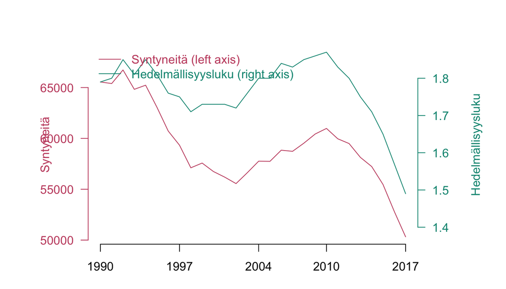

Toinen syntyneiden määrää selittävä tekijä on synnytysikäisten naisten lukumäärä. Kun tarkastellaan 25-29 -vuotiaiden naisten määrää, näkyy, että vuoteen 2010 asti köyrät kulkevat yhtä matkaa. Sen jälkeen ne erkautuvat.

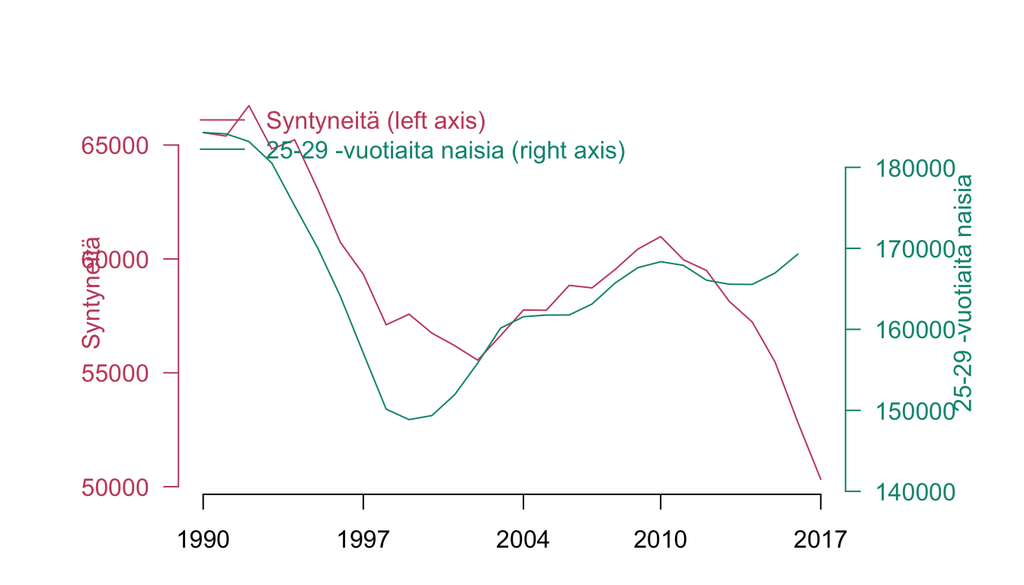

Sama ilmiö näkyy myös 30-34 -vuotiaiden naisten määrässä

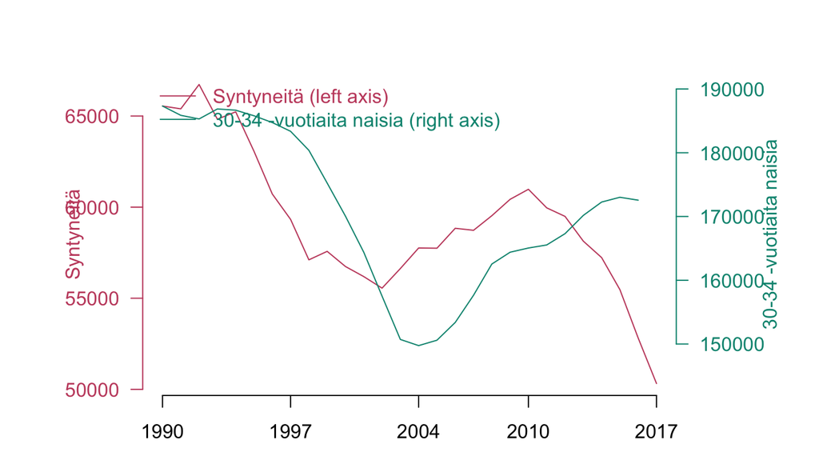

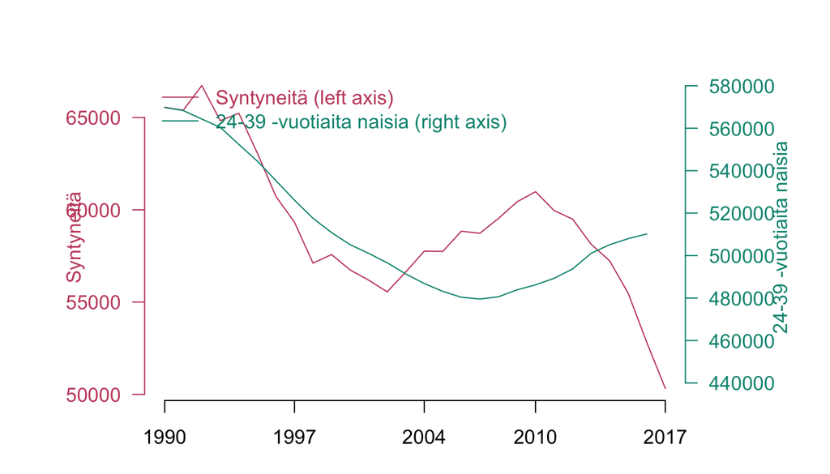

Sisemmässä kaupungissa asuvien osuus väestöstä Suomessa on vahvasti negatiivisesti korreloitunut hedelmällisyysluvun kanssa

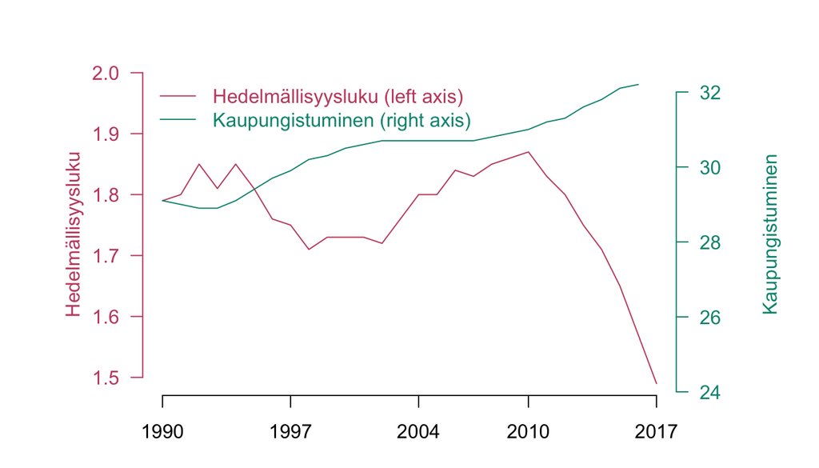

Avioituvuus on korreloitunut hedelmällisyysluvun kanssa

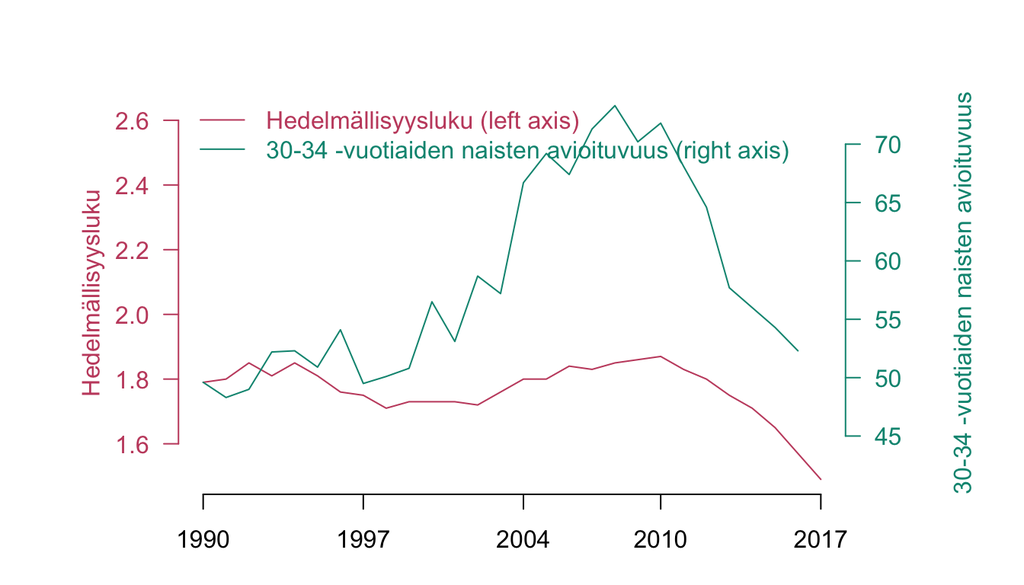

## Mikä selittää vaihtelun syntyneiden lasten määrässä?

Aloitetaan yksinkertaisesta mallista syntyneiden lukumäärälle: mukana vain hedelmällisyysluku ja synnytysikäisten naisten lukumäärät. Kokonaishedelmällisyysluku kuvaa “Kokonaishedelmällisyysluku saadaan laskemalla yhteen yhdelle ikävuodelle lasketut hedelmällisyysluvut” (Tilastokeskus), joten se on hyvin lähellä syntyvyyttä per nainen kunakin vuonna. Kun huomioidaan naisten lukumäärän muutos, pitäisi tuloksena olla hyvin syntyvyyden muutoksia selittävä malli. Arvioidaan näille tekijöille regressiokertoimet bayesilaisilla menetelmillä.

```r
syntyvyys_base = bas.lm(syntyneita ~ hedelmallisyysluku + naisten_lkm_15_19 + naisten_lkm_20_24 +naisten_lkm_25_29 + naisten_lkm_30_34 +naisten_lkm_35_39 + naisten_lkm_40_45 + naisten_lkm_45_49,
data = syntyvyysaineisto_redusoitu, prior = "ZS-null", modelprior = uniform())
```

Sovite on bayesilainen, jossa eri mallien prioritodennäköisyytenä on käytetty samaa arvoa. Sovite antaa todennäköisyydet malleille.

```
##                    P(B != 0 | Y) model 1 model 2 model 3
## Intercept                  1.000   1.000   1.000   1.000
## hedelmallisyysluku         1.000   1.000   1.000   1.000
## naisten_lkm_15_19          0.018   0.000   0.000   0.000
## naisten_lkm_20_24          0.986   1.000   1.000   1.000
## naisten_lkm_25_29          1.000   1.000   1.000   1.000
## naisten_lkm_30_34          1.000   1.000   1.000   1.000
## naisten_lkm_35_39          1.000   1.000   1.000   1.000
## naisten_lkm_40_45          0.028   0.000   1.000   0.000
## naisten_lkm_45_49          0.033   0.000   0.000   1.000
## BF                            NA   1.000   0.025   0.021
## PostProbs                     NA   0.926   0.023   0.020
## R2                            NA   0.999   0.999   0.999
## dim                           NA   6.000   7.000   7.000
## logmarg                       NA  63.946  60.252  60.094
```

Bayes-faktorimalleista paras on malli, jossa on viisi faktoria ja vakiotermi: hedelmällisyysluku, 20-24 -vuotiaiden, 25-29 -vuotiaiden, 30-34 -vuotiaiden ja 35-39 -vuotiaiden naisten lukumäärät. Muutokset näissä viidessä faktorissa riittävät selittämään 99,9 % muutoksista syntyvyydessä (tarkemmin, varianssista).

Regressiokertoimien suuruudesta näkyy, että tärkeimmät faktorit ovat hedelmällisyysluku ja 25-29 sekä 30-34 -vuotiaiden naisten lukumäärä. Tämä vastaa tietoa, että synnyttäneiden keski-ikä on juuri tällä välillä (29 vuotta 1989 ja 30,7 vuotta 2016). Suurin osa synnyttäneistä on juuri 25-34 -vuotiaita.

```
##
##  Marginal Posterior Summaries of Coefficients:
##
##  Using  BMA
##
##  Based on the top  256 models
##                     post mean   post SD     post p(B != 0)
## Intercept            5.955e+04   2.308e+01   1.000e+00
## hedelmallisyysluku   3.391e+04   5.059e+02   1.000e+00
## naisten_lkm_15_19    9.915e-06   3.030e-03   1.847e-02
## naisten_lkm_20_24    3.933e-02   7.630e-03   9.865e-01
## naisten_lkm_25_29    1.116e-01   3.933e-03   1.000e+00
## naisten_lkm_30_34    1.053e-01   3.057e-03   1.000e+00
## naisten_lkm_35_39    6.181e-02   2.389e-03   1.000e+00
## naisten_lkm_40_45   -1.253e-04   1.076e-03   2.815e-02
## naisten_lkm_45_49   -1.281e-04   2.283e-03   3.348e-02
```

Erikoista kyllä, 40-44 ja 45-49-vuotiaiden naisten regressiokertoimet ovat negatiivisia, mikä vaikuttaa erikoiselta, mutta niiden faktorien todennäköisyys on vähäinen, juuri niinkuin intuitiokin sanoo.

Kun verrataan sovitetta aineistoon, näkyy että erot ovat datan ja mallin välillä erittäin pienet

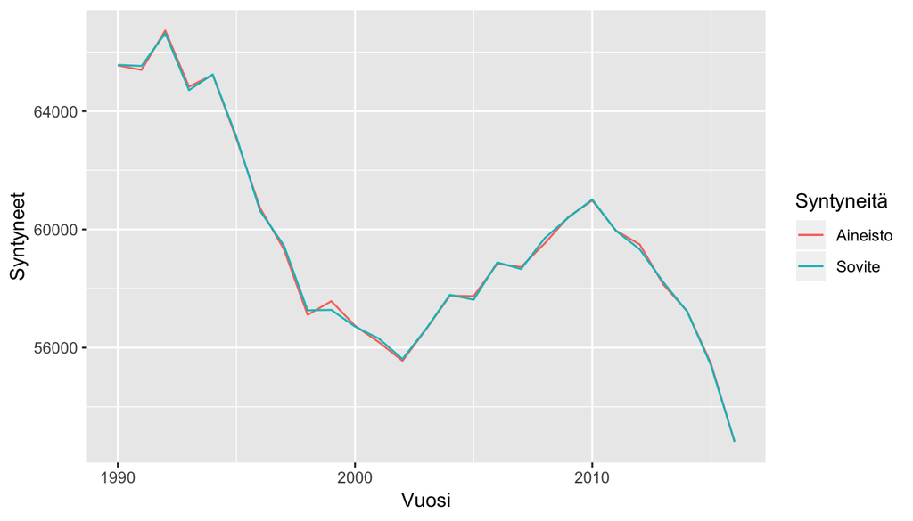

Tarkastetaan vielä, millaisia residuaaleja jää selittämättä mallilla. Residuaalit käyttäytyvät hyvin, joten faktorimalli kuvaa syntyvyyden muutoksia.

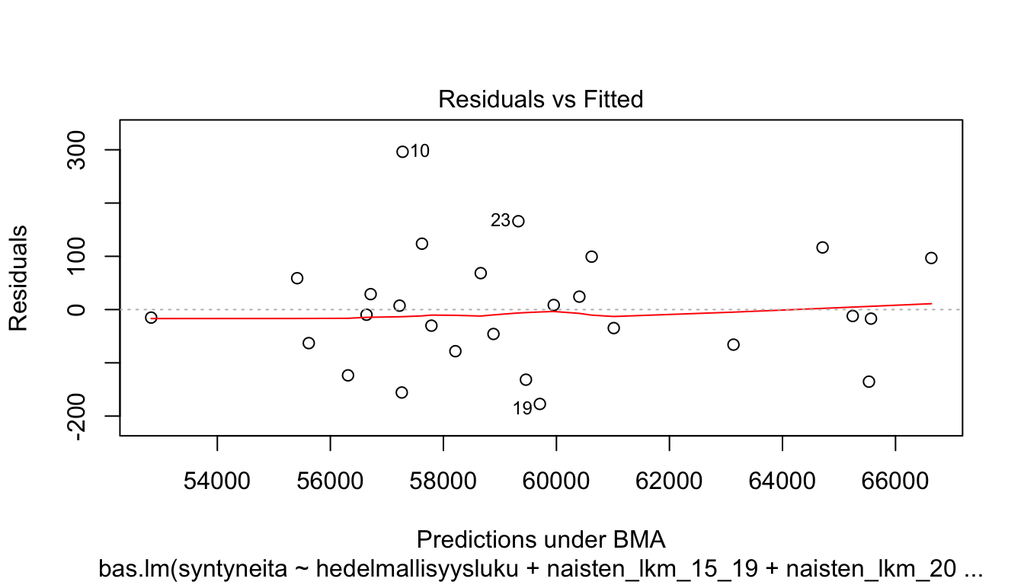

Havainnollisuuden vuoksi voi sanoa, että syntyneiden määrälle regressio ehdottaa yksinkertaisen mallin
$$S=59550+33910H+0.038N_{20-24}+0.116N_{25-29}+0.105N_{30-34}+0.0618N_{35-39}$$

missä H on hedelmällisyysluvun poikkeama vuosien 1989-2017 keskiarvosta ja N_{x-y}:t ovat x-y -ikäisten naisten lukumäärien poikkeamia vuosien 1989-2017 keskiarvosta. Tulkinta vakiotermille tässä yhteydessä on se, että se huomioi faktoreiden keskiarvojen vaikutuksen syntyneiden lukumäärään. Tämä regressiomalli ei tietenkään huomioi epävarmuutta, joka näkyy täydellisessä Bayes-mallissa. Mallin selitysvoima osoittaa, että menetelmä näyttää toimivan juuri niin kuin tarkoitus on.

## Pidempi aineisto

Yllä tarkasteltu malli toimi erinomaisesti vuosien 1989-2016 aineistolla. Siinä kuitenkin oletetaan että eri 5-vuotisikäryhmien painot säilyvät samoina koko aikavälin, vaikka tiedetään että synnyttäneiden keski-ikä on noussut.  
Jotta nähdään, onko tällä vaikutusta, ajetaan sama malli pidemmälle aineistolle, vuosien 1970-2017 aineistolla.

```r
syntyvyys_long = bas.lm(syntyneita ~ hedelmallisyysluku + naisten_lkm_15_19 + naisten_lkm_20_24 + naisten_lkm_25_29 + naisten_lkm_30_34 +naisten_lkm_35_39 +  naisten_lkm_40_45 + naisten_lkm_45_49,
data = fertility_data, prior = "ZS-null", modelprior = uniform())
```

```
##                    P(B != 0 | Y) model 1 model 2 model 3
## Intercept                  1.000   1.000   1.000   1.000
## hedelmallisyysluku         1.000   1.000   1.000   1.000
## naisten_lkm_15_19          0.063   0.000   1.000   0.000
## naisten_lkm_20_24          1.000   1.000   1.000   1.000
## naisten_lkm_25_29          1.000   1.000   1.000   1.000
## naisten_lkm_30_34          1.000   1.000   1.000   1.000
## naisten_lkm_35_39          1.000   1.000   1.000   1.000
## naisten_lkm_40_45          0.948   1.000   1.000   0.000
## naisten_lkm_45_49          0.999   1.000   1.000   1.000
## BF                            NA   1.000   0.066   0.055
## PostProbs                     NA   0.888   0.059   0.049
## R2                            NA   0.985   0.985   0.980
## dim                           NA   8.000   9.000   7.000
## logmarg                       NA  72.666  69.950  69.764
```

Regressiokertoimien suuruudesta näkyy, että nyt 20-24 ja 25-29 -vuotiaiden naisten lukumäärät vaikuttavat vahvemmin syntyneiden määrään. Tämä on järkevää, koska tarkasteluperiodin aikana synnyttäneiden keski-ikä on kasvanut.

```
##
##  Marginal Posterior Summaries of Coefficients:
##
##  Using  BMA
##
##  Based on the top  256 models
##                     post mean  post SD    post p(B != 0)
## Intercept           6.087e+04  7.578e+01  1.000e+00
## hedelmallisyysluku  3.260e+04  1.080e+03  1.000e+00
## naisten_lkm_15_19   5.166e-04  4.136e-03  6.291e-02
## naisten_lkm_20_24   1.594e-01  1.167e-02  1.000e+00
## naisten_lkm_25_29   1.235e-01  6.938e-03  1.000e+00
## naisten_lkm_30_34   9.786e-02  6.968e-03  1.000e+00
## naisten_lkm_35_39   3.230e-02  6.637e-03  9.996e-01
## naisten_lkm_40_45   2.106e-02  7.667e-03  9.483e-01
## naisten_lkm_45_49   4.525e-02  8.385e-03  9.987e-01
```

Sovite on edelleenkin hyvä, mutta selviä eroja näkyy nyt faktorimallin ja data välillä.

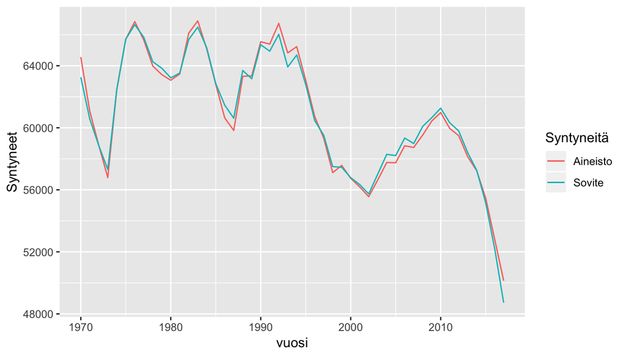

Tarkastetaan vielä, millaisia residuaaleja jää selittämättä mallilla. Nyt residuaalit tasoa kuvaava punainen käyrä ei olekaan suora, mikä viittaa siihen että vuosien varrella tapahtuu muutos, jota tämä malli ei pysty selittämään.

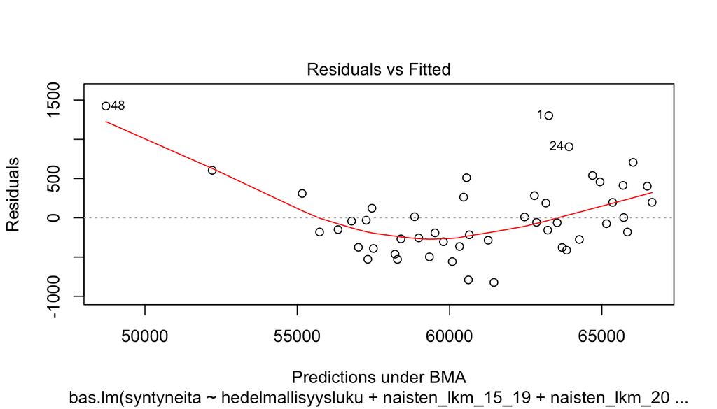

# Hedelmällisyysluvun muutoksia selittävä malli

Synnytysikäisten naisten lukumäärää pystytään ennustamaan melko hyvin, eikä siihen vaikuta juurikaan muut tekijät, kuten vaikkapa työllisyys tai taloudellinen tilanne. Jos sellaiset tekijät vaikuttavat syntyvyyteen, vaikutuksen pitäisi näkyä hedelmällisyysluvussa.

Yritetään sitten selittää hedelmällisyysluvun muutoksia käyttäen faktoreina kokoelmaa erilaisia tekijöitä ikäluokka- ja sukupuolikohtaisia avioituvuuksia ja pienituloisuusosuusasteita (60% mediaanitulosta); synnyttäjien keski-ikää, alle 1-vuotiaiden kuolleisuutta, eläkemenon bkt-osuutta, sekä sisäkaupungissa, ulkokaupungissa ja maaseudulla asuvien osuutta väestöstä.

```r
syntyvyys_reg = bas.lm(hedelmallisyysluku ~pienituloisuus_18_24 + pienituloisuus_25_34 + lapsikuolleisuus + synnyttajien_keskiika + avioituvuus_naiset_25_29_lag1 + avioituvuus_naiset_30_34_lag1 + elakemeno + kaupungissaasuvat + maaseudulla + sisakaupungissa, data = syntyvyysaineisto_redusoitu,
prior = "ZS-null", modelprior = uniform())
```

Tuloksissa parhaana näkyy kolmen faktorin ja vakiotermin malli, jossa faktoreina ovat 25-29-vuotiaiden avioituvuus, sisäkaupungissa ja muualla kaupungissa asuvien osuus. Näillä faktoreilla on mahdollista selittää noin 92 % hedelmällisyysluvun varianssista datassa. Hieman yllättäen synnyttäjien keski-ikä ei näy mallissa merkittävänä tekijänä.

```
##                               P(B != 0 | Y) model 1 model 2 model 3
## Intercept                             1.000   1.000   1.000   1.000
## pienituloisuus_18_24                  0.206   0.000   0.000   0.000
## pienituloisuus_25_34                  0.170   0.000   0.000   0.000
## lapsikuolleisuus                      0.146   0.000   0.000   0.000
## synnyttajien_keskiika                 0.287   0.000   0.000   0.000
## avioituvuus_naiset_25_29_lag1         0.591   1.000   0.000   0.000
## avioituvuus_naiset_30_34_lag1         0.537   0.000   1.000   1.000
## elakemeno                             0.218   0.000   0.000   0.000
## kaupungissaasuvat                     0.679   1.000   0.000   1.000
## maaseudulla                           0.232   0.000   0.000   0.000
## sisakaupungissa                       0.923   1.000   1.000   1.000
## BF                                       NA   1.000   0.373   0.208
## PostProbs                                NA   0.160   0.060   0.033
## R2                                       NA   0.922   0.896   0.910
## dim                                      NA   4.000   3.000   4.000
## logmarg                                  NA  23.368  22.383  21.799
```

Todennäköisimmässä mallissa regressiokertoimet ovat

```
##
##  Marginal Posterior Summaries of Coefficients:
##
##  Using  HPM
##
##  Based on the top  1 models
##                                post mean  post SD    post p(B != 0)
## Intercept                       1.776296   0.003982   1.000000
## pienituloisuus_18_24            0.000000   0.000000   0.205574
## pienituloisuus_25_34            0.000000   0.000000   0.169991
## lapsikuolleisuus                0.000000   0.000000   0.145603
## synnyttajien_keskiika           0.000000   0.000000   0.287413
## avioituvuus_naiset_25_29_lag1   0.007458   0.001022   0.590711
## avioituvuus_naiset_30_34_lag1   0.000000   0.000000   0.536778
## elakemeno                       0.000000   0.000000   0.218424
## kaupungissaasuvat               0.074730   0.008616   0.678634
## maaseudulla                     0.000000   0.000000   0.232215
## sisakaupungissa                -0.151944   0.025115   0.923196
```

Regressiokertoimista näkyy, että avioituvuus lisää syntyvyyttä, mutta maltillisesti: yhden prosenttiyksikön nousu avioituvuudessa kytkeytyisi hedelmällisyysluvun kasvuun 1,49:stä 1,497:ään. Viivästetty avioituvuus on laskenut 15,9 prosenttiyksikköä 25-29-vuotiaissa vuodesta 2010 vuoteen 2016, jolloin mallin mukaan sillä voi selittää 0,119:n verran hedelmällisyysluvun pudotuksesta.

Kaupungistuminen liittyy jälleen regression mukaan hedelmällisyyslukuun: sisäkaupungissa asuvien osuuden kasvu alentaa hedelmällisyyslukua (kerroin -0.151944) ja muualla kaupungissa asuvien osuuden kasvu kasvattaa hedelmällisyyslukua (kerroin 0.074730). Tiedetään, että Suomen suurissa kaupungeissa on alimmat hedelmällisyysluvut, joten tulos on uskottava. Vuodesta 2010 vuoteen 2016 muualla kaupungissa asuvien osuus on kasvanut 1,8 prosenttiyksikkö ja sisäkaupungissa asuvien osuus on kasvanut 1,2 prosenttiyksikköä. Näiden yhteisvaikutus hedelmällisyyslukuun on lasku 0,048:n verran.

Vuosien 2010 ja 2016 välisestä hedelmällisyysluvun 0,30:n pudotuksesta nämä kolme faktorit selittävät hieman yli puolet (0,166).

Aggregaattikertoimet kaikissa mallissa todennäköisyyksillä painotettuna ovat

```
##
##  Marginal Posterior Summaries of Coefficients:
##
##  Using  BMA
##
##  Based on the top  1024 models
##                                post mean   post SD     post p(B != 0)
## Intercept                       1.7762963   0.0042159   1.0000000
## pienituloisuus_18_24            0.0005107   0.0014863   0.2055740
## pienituloisuus_25_34            0.0006351   0.0036741   0.1699911
## lapsikuolleisuus                0.7605645   7.1858565   0.1456033
## synnyttajien_keskiika          -0.0276005   0.0580031   0.2874134
## avioituvuus_naiset_25_29_lag1   0.0036879   0.0036256   0.5907106
## avioituvuus_naiset_30_34_lag1   0.0033072   0.0035642   0.5367776
## elakemeno                      -0.0005705   0.0047726   0.2184236
## kaupungissaasuvat               0.0471566   0.0420595   0.6786338
## maaseudulla                     0.0003707   0.0277859   0.2322153
## sisakaupungissa                -0.1242212   0.0621394   0.9231963
```

Tarkastetaan vielä, millaisia residuaaleja jää selittämättä mallilla

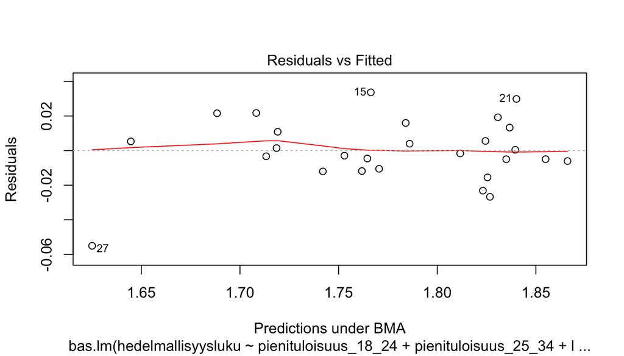

Ja lopuksi verrataan mallin sovitetta

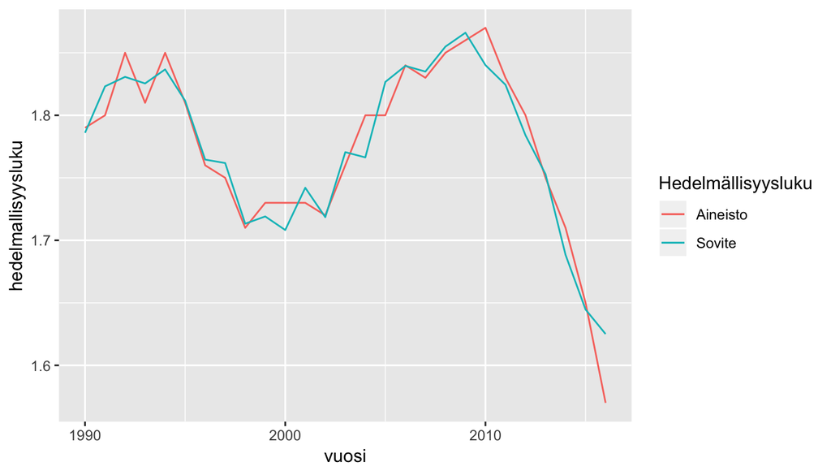

Residuaaleista näkee, että malli selittää heikoimmin viimeisimpiä havaintoja (erityisesti outlier #27). Aiemmin laskettiin, että juuri tällä aikavälillä faktorit selittivät vain hieman yli puolet varianssista.

## Työttömyys ja pienituloisuus ja hedelmällisyysluvun muutokset

Yritetään sitten selittää hedelmällisyysluvun muutoksia käyttäen faktoreina viivästettyjä 10-vuotisikäluokka- ja sukupuolikohtaisia työttömien osuutta kohortista, työttömyysasteita ja työvoimanulkopuolisuusasteita; pienituloisuusosuusasteita (60% mediaanitulosta), synnyttäjien keski-ikää, avioituvuutta, eläkemenon osuutta BKT:stä sekä ulommassa kaupungissa, maaseudulla ja sisemmässä kaupungissa asuvien osuuksia.

```r
syntyvyys_reg = bas.lm(hedelmallisyysluku ~pienituloisuus_18_24 + pienituloisuus_25_34
+ tyottomyys_per_vaesto_miehet_25_34_lag1 +tyottomyys_per_vaesto_miehet_35_44_lag1
+ tyottomyys_per_vaesto_naiset_25_34_lag1 +tyottomyys_per_vaesto_naiset_35_44_lag1
+ tyollisyysaste_miehet_25_34_lag1 +tyollisyysaste_naiset_25_34_lag1
+ tyollisyysaste_miehet_35_44_lag1 +tyollisyysaste_naiset_35_44_lag1
+ ulkopuoliset_naiset_25_34_lag1 +ulkopuoliset_miehet_25_34_lag1
+ synnyttajien_keskiika + elakemeno + lapsikuolleisuus
+ avioituvuus_naiset_25_29_lag1 + avioituvuus_naiset_30_34_lag1
+ kaupungissaasuvat + maaseudulla + sisakaupungissa,
data = syntyvyysaineisto_redusoitu, prior = "ZS-null", modelprior = uniform())
```

```
##                                         P(B != 0 | Y) model 1 model 2
## Intercept                                       1.000   1.000   1.000
## pienituloisuus_18_24                            0.406   0.000   0.000
## pienituloisuus_25_34                            0.166   0.000   0.000
## tyottomyys_per_vaesto_miehet_25_34_lag1         0.361   0.000   1.000
## tyottomyys_per_vaesto_miehet_35_44_lag1         0.286   0.000   0.000
## tyottomyys_per_vaesto_naiset_25_34_lag1         0.234   0.000   0.000
## tyottomyys_per_vaesto_naiset_35_44_lag1         0.204   0.000   0.000
## tyollisyysaste_miehet_25_34_lag1                0.260   0.000   0.000
## tyollisyysaste_naiset_25_34_lag1                0.226   0.000   0.000
## tyollisyysaste_miehet_35_44_lag1                0.233   0.000   0.000
## tyollisyysaste_naiset_35_44_lag1                0.230   0.000   0.000
## ulkopuoliset_naiset_25_34_lag1                  0.155   0.000   0.000
## ulkopuoliset_miehet_25_34_lag1                  0.175   0.000   0.000
## synnyttajien_keskiika                           0.675   0.000   1.000
## elakemeno                                       0.216   0.000   0.000
## lapsikuolleisuus                                0.153   0.000   0.000
## avioituvuus_naiset_25_29_lag1                   0.296   1.000   0.000
## avioituvuus_naiset_30_34_lag1                   0.850   0.000   1.000
## kaupungissaasuvat                               0.402   1.000   1.000
## maaseudulla                                     0.273   0.000   0.000
## sisakaupungissa                                 0.408   1.000   0.000
## BF                                                 NA   1.000   0.523
## PostProbs                                          NA   0.007   0.004
## R2                                                 NA   0.922   0.932
## dim                                                NA   4.000   5.000
## logmarg                                            NA  23.368  22.719
##                                         model 3
## Intercept                                 1.000
## pienituloisuus_18_24                      0.000
## pienituloisuus_25_34                      0.000
## tyottomyys_per_vaesto_miehet_25_34_lag1   0.000
## tyottomyys_per_vaesto_miehet_35_44_lag1   1.000
## tyottomyys_per_vaesto_naiset_25_34_lag1   0.000
## tyottomyys_per_vaesto_naiset_35_44_lag1   0.000
## tyollisyysaste_miehet_25_34_lag1          0.000
## tyollisyysaste_naiset_25_34_lag1          0.000
## tyollisyysaste_miehet_35_44_lag1          0.000
## tyollisyysaste_naiset_35_44_lag1          0.000
## ulkopuoliset_naiset_25_34_lag1            0.000
## ulkopuoliset_miehet_25_34_lag1            0.000
## synnyttajien_keskiika                     1.000
## elakemeno                                 0.000
## lapsikuolleisuus                          0.000
## avioituvuus_naiset_25_29_lag1             0.000
## avioituvuus_naiset_30_34_lag1             1.000
## kaupungissaasuvat                         1.000
## maaseudulla                               0.000
## sisakaupungissa                           0.000
## BF                                        0.430
## PostProbs                                 0.003
## R2                                        0.930
## dim                                       5.000
## logmarg                                  22.525
```

Sisemmässä kaupungissa asuvien osuus liittyy regression mukaan hedelmällisyyslukuun kertoimella -0,039. Tällöin 1 %-yksikön kasvu sisemmässä kaupungissa asuvien osuudessa alentaisi hedelmällisyyslukua 1,49:stä 1,45:een. Tiedetään, että Suomen suurissa kaupungeissa on alimmat hedelmällisyysluvut, joten tulos on uskottava.

Synnyttäjien keski-ikä kytkeytyy vahvasti hedelmällisyyslukuun (-0,15). Jos synnyttäjien keski-ikä alenisi yhden vuoden, kasvaisi hedelmällisyysluku 1,49:stä 1,64:ään, mikäli arvio regressiokertoimesta on oikea.

```
##
##  Marginal Posterior Summaries of Coefficients:
##
##  Using  BMA
##
##  Based on the top  524288 models
##                                          post mean   post SD
## Intercept                                 1.776e+00   4.070e-03
## pienituloisuus_18_24                      1.799e-03   2.751e-03
## pienituloisuus_25_34                     -1.568e-04   3.050e-03
## tyottomyys_per_vaesto_miehet_25_34_lag1   4.484e-03   1.069e-02
## tyottomyys_per_vaesto_miehet_35_44_lag1   2.817e-03   9.288e-03
## tyottomyys_per_vaesto_naiset_25_34_lag1  -1.486e-03   5.356e-03
## tyottomyys_per_vaesto_naiset_35_44_lag1  -5.515e-04   4.897e-03
## tyollisyysaste_miehet_25_34_lag1          1.344e-04   8.262e-03
## tyollisyysaste_naiset_25_34_lag1          7.627e-04   4.235e-03
## tyollisyysaste_miehet_35_44_lag1          9.190e-04   6.286e-03
## tyollisyysaste_naiset_35_44_lag1          1.434e-03   4.413e-03
## ulkopuoliset_naiset_25_34_lag1           -3.042e-05   3.763e-03
## ulkopuoliset_miehet_25_34_lag1            1.226e-03   8.445e-03
## synnyttajien_keskiika                    -1.460e-01   1.288e-01
## elakemeno                                -1.268e-03   5.245e-03
## lapsikuolleisuus                          1.163e+00   8.676e+00
## avioituvuus_naiset_25_29_lag1             1.101e-03   2.848e-03
## avioituvuus_naiset_30_34_lag1             5.995e-03   3.027e-03
## kaupungissaasuvat                         2.107e-02   3.774e-02
## maaseudulla                               1.644e-03   3.345e-02
## sisakaupungissa                          -3.938e-02   6.565e-02
##                                          post p(B != 0)
## Intercept                                 1.000e+00
## pienituloisuus_18_24                      4.061e-01
## pienituloisuus_25_34                      1.661e-01
## tyottomyys_per_vaesto_miehet_25_34_lag1   3.606e-01
## tyottomyys_per_vaesto_miehet_35_44_lag1   2.860e-01
## tyottomyys_per_vaesto_naiset_25_34_lag1   2.335e-01
## tyottomyys_per_vaesto_naiset_35_44_lag1   2.036e-01
## tyollisyysaste_miehet_25_34_lag1          2.597e-01
## tyollisyysaste_naiset_25_34_lag1          2.260e-01
## tyollisyysaste_miehet_35_44_lag1          2.325e-01
## tyollisyysaste_naiset_35_44_lag1          2.300e-01
## ulkopuoliset_naiset_25_34_lag1            1.547e-01
## ulkopuoliset_miehet_25_34_lag1            1.753e-01
## synnyttajien_keskiika                     6.753e-01
## elakemeno                                 2.159e-01
## lapsikuolleisuus                          1.529e-01
## avioituvuus_naiset_25_29_lag1             2.956e-01
## avioituvuus_naiset_30_34_lag1             8.502e-01
## kaupungissaasuvat                         4.019e-01
## maaseudulla                               2.725e-01
## sisakaupungissa                           4.080e-01
```

Hieman yllättäen työttömyys- tai työllisyysasteet liittyvät hedelmällisyyslukuun melko pienellä todennäköisyydellä. Bayesilainen keskiarvoregressiokerroin on suuruusluokkaa 0,005. Tällöin yhden prosenttiyksikön muutos työllisyydessä tai työttömyydessä muuttaisi hedelmällisyyslukua vain 0,005. Kaikkien työllisyysastetekijöiden regressiokerroin on positiivinen, mikä tarkoittaa, että työllisyysasteen kasvu nostaisi hedelmällisyyslukua hienoisesti. Työttömyyttä kuvaavien tekijöiden kerrointen etumerkit ovat erikoisempia: miesten kertoimien mukaan työttömyyden kasvu nostaisi hedelmällisyyslukua, mutta naisten alentaisi.

Tarkastetaan vielä, millaisia residuaaleja jää selittämättä mallilla

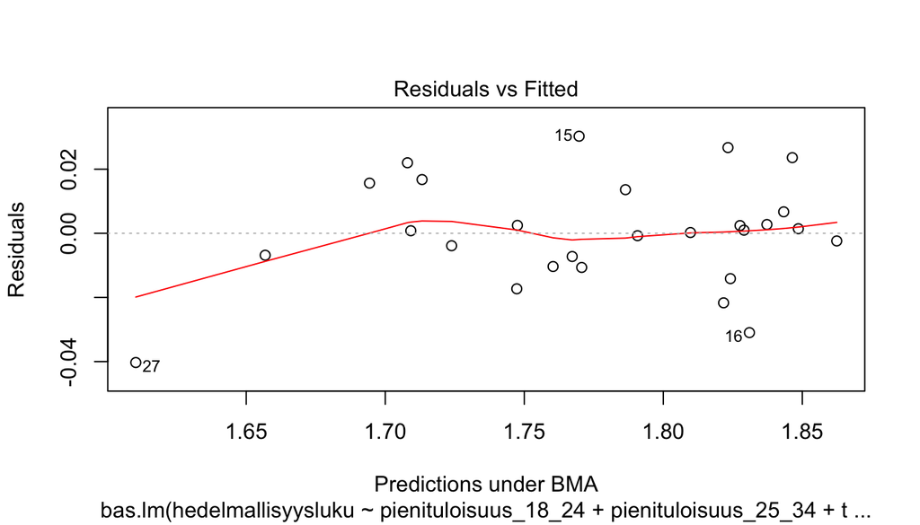

Ja lopuksi verrataan mallin sovitetta

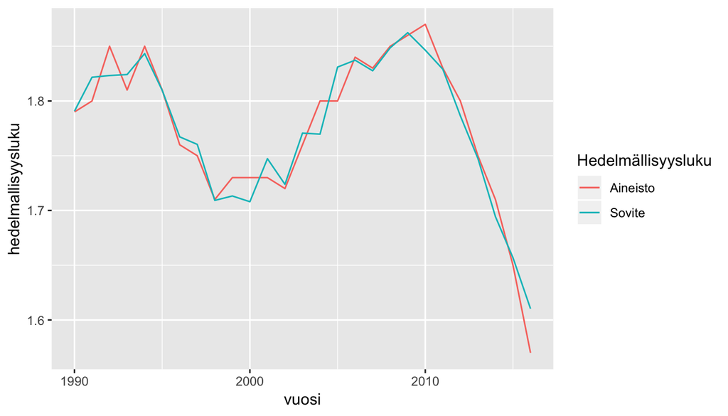

# Lyhyt aineisto

```r
syntyvyys_reg = bas.lm(hedelmallisyysluku ~pienituloisuus_18_24 + pienituloisuus_25_34 +
+ tyottomyys_per_vaesto_miehet_25_34_lag1 +tyottomyys_per_vaesto_miehet_35_44_lag1
+ tyottomyys_per_vaesto_naiset_25_34_lag1 +tyottomyys_per_vaesto_naiset_35_44_lag1
+ tyollisyysaste_miehet_25_34_lag1 +tyollisyysaste_naiset_25_34_lag1
+ tyollisyysaste_miehet_35_44_lag1 +tyollisyysaste_naiset_35_44_lag1
+ ulkopuoliset_naiset_25_34_lag1 +ulkopuoliset_miehet_25_34_lag1
+ synnyttajien_keskiika + lapsikuolleisuus + elakemeno
+ avioituvuus_naiset_25_29_lag1 + avioituvuus_naiset_30_34_lag1
+ kaupungissaasuvat + maaseudulla + sisakaupungissa,
data = syntyvyysaineisto_lyhyt,
prior = "ZS-null", modelprior = uniform())
```

Tuloksista näkyy selvästi, että samat tekijät kuin aiemmin ovat merkittäviä: sisemmässä kaupungissa ja maaseudulla asuvien osuus väestöstä sekä synnyttäjien keski-ikä kytkeytyy selvästi hedelmällisyyslukuun. Kuitenkin toisin kuin yllä, 25-34 -vuotiaiden naisten työttömyysaste vaikuttaa hedelmällisyyslukuun, ja jossain määrin myös 25-34 -vuotiaiden miesten työllisyys (osassa malleja työttömyysaste, osassa työllisyysaste). Avioituvuus ja pienituloisuus eivät tässä aineistossa näytä vaikuttavan hedelmällisyyslukuun.

```
##                                         P(B != 0 | Y) model 1 model 2
## Intercept                                       1.000   1.000   1.000
## pienituloisuus_18_24                            0.138   0.000   0.000
## pienituloisuus_25_34                            0.288   0.000   0.000
## tyottomyys_per_vaesto_miehet_25_34_lag1         0.351   0.000   1.000
## tyottomyys_per_vaesto_miehet_35_44_lag1         0.202   0.000   0.000
## tyottomyys_per_vaesto_naiset_25_34_lag1         0.787   1.000   1.000
## tyottomyys_per_vaesto_naiset_35_44_lag1         0.149   0.000   0.000
## tyollisyysaste_miehet_25_34_lag1                0.340   1.000   0.000
## tyollisyysaste_naiset_25_34_lag1                0.152   0.000   0.000
## tyollisyysaste_miehet_35_44_lag1                0.217   0.000   0.000
## tyollisyysaste_naiset_35_44_lag1                0.191   0.000   0.000
## ulkopuoliset_naiset_25_34_lag1                  0.151   0.000   0.000
## ulkopuoliset_miehet_25_34_lag1                  0.171   0.000   0.000
## synnyttajien_keskiika                           0.604   1.000   1.000
## lapsikuolleisuus                                0.170   0.000   0.000
## elakemeno                                       0.242   0.000   0.000
## avioituvuus_naiset_25_29_lag1                   0.135   0.000   0.000
## avioituvuus_naiset_30_34_lag1                   0.209   0.000   0.000
## kaupungissaasuvat                               0.454   0.000   0.000
## maaseudulla                                     0.494   1.000   1.000
## sisakaupungissa                                 0.952   1.000   1.000
## BF                                                 NA   1.000   0.466
## PostProbs                                          NA   0.020   0.010
## R2                                                 NA   0.986   0.984
## dim                                                NA   6.000   6.000
## logmarg                                            NA  20.690  19.927
##                                         model 3
## Intercept                                 1.000
## pienituloisuus_18_24                      0.000
## pienituloisuus_25_34                      1.000
## tyottomyys_per_vaesto_miehet_25_34_lag1   1.000
## tyottomyys_per_vaesto_miehet_35_44_lag1   0.000
## tyottomyys_per_vaesto_naiset_25_34_lag1   1.000
## tyottomyys_per_vaesto_naiset_35_44_lag1   0.000
## tyollisyysaste_miehet_25_34_lag1          0.000
## tyollisyysaste_naiset_25_34_lag1          0.000
## tyollisyysaste_miehet_35_44_lag1          0.000
## tyollisyysaste_naiset_35_44_lag1          0.000
## ulkopuoliset_naiset_25_34_lag1            0.000
## ulkopuoliset_miehet_25_34_lag1            0.000
## synnyttajien_keskiika                     0.000
## lapsikuolleisuus                          0.000
## elakemeno                                 0.000
## avioituvuus_naiset_25_29_lag1             0.000
## avioituvuus_naiset_30_34_lag1             0.000
## kaupungissaasuvat                         1.000
## maaseudulla                               0.000
## sisakaupungissa                           1.000
## BF                                        0.348
## PostProbs                                 0.007
## R2                                        0.983
## dim                                       6.000
## logmarg                                  19.633
```

Viivästetty 25-34 -vuotiaiden naisten työttömyysaste kytkeytyy hedelmällisyyslukuun, mutta sen keskiarvoregressiokertoimet on -0,023. Naisten työttömyysasteen kasvaessa hedelmällisyysluku siis pienenee, mutta hyvin maltillisesti: yhden prosenttiyksikön kasvu työttömyysasteessa alentaisi hedelmällisyyslukua vain 0,023. Sitä vastoin 25-34 -vuotiaiden miesten työttömyysasteen ja työllisyysasteen muutos viittaa toisensuuntaiseen hedelmällisyysluvun muutokseen. Miesten työllisyysasteet eivät ehkä kuitenkaan kytkeydy hedelmällisyyslukuun tai sitten työttömyyden kasvu tosiaan lisää syntyvyyttä. Lyhyen aineiston johdosta ensimmäinen vaihtoehto näyttää uskottavammalta.

```
##
##  Marginal Posterior Summaries of Coefficients:
##
##  Using  BMA
##
##  Based on the top  524288 models
##                                          post mean   post SD
## Intercept                                 1.7652632   0.0032987
## pienituloisuus_18_24                      0.0001415   0.0012198
## pienituloisuus_25_34                      0.0025467   0.0060481
## tyottomyys_per_vaesto_miehet_25_34_lag1   0.0048901   0.0098788
## tyottomyys_per_vaesto_miehet_35_44_lag1   0.0010379   0.0075711
## tyottomyys_per_vaesto_naiset_25_34_lag1  -0.0234417   0.0164778
## tyottomyys_per_vaesto_naiset_35_44_lag1   0.0005270   0.0058509
## tyollisyysaste_miehet_25_34_lag1         -0.0033916   0.0089501
## tyollisyysaste_naiset_25_34_lag1          0.0005681   0.0076687
## tyollisyysaste_miehet_35_44_lag1          0.0014170   0.0062812
## tyollisyysaste_naiset_35_44_lag1          0.0011938   0.0039628
## ulkopuoliset_naiset_25_34_lag1            0.0003768   0.0076712
## ulkopuoliset_miehet_25_34_lag1            0.0005307   0.0085091
## synnyttajien_keskiika                    -0.1688763   0.1691114
## lapsikuolleisuus                         -2.1298535  14.9821446
## elakemeno                                 0.0030332   0.0072431
## avioituvuus_naiset_25_29_lag1             0.0000245   0.0010377
## avioituvuus_naiset_30_34_lag1             0.0005608   0.0017125
## kaupungissaasuvat                         0.0300365   0.0461003
## maaseudulla                              -0.0359109   0.0528270
## sisakaupungissa                          -0.2188063   0.0829466
##                                          post p(B != 0)
## Intercept                                 1.0000000
## pienituloisuus_18_24                      0.1381801
## pienituloisuus_25_34                      0.2877804
## tyottomyys_per_vaesto_miehet_25_34_lag1   0.3506064
## tyottomyys_per_vaesto_miehet_35_44_lag1   0.2015618
## tyottomyys_per_vaesto_naiset_25_34_lag1   0.7873374
## tyottomyys_per_vaesto_naiset_35_44_lag1   0.1494825
## tyollisyysaste_miehet_25_34_lag1          0.3400216
## tyollisyysaste_naiset_25_34_lag1          0.1517820
## tyollisyysaste_miehet_35_44_lag1          0.2167977
## tyollisyysaste_naiset_35_44_lag1          0.1913015
## ulkopuoliset_naiset_25_34_lag1            0.1507801
## ulkopuoliset_miehet_25_34_lag1            0.1712949
## synnyttajien_keskiika                     0.6040154
## lapsikuolleisuus                          0.1702523
## elakemeno                                 0.2422186
## avioituvuus_naiset_25_29_lag1             0.1346908
## avioituvuus_naiset_30_34_lag1             0.2094263
## kaupungissaasuvat                         0.4535059
## maaseudulla                               0.4935165
## sisakaupungissa                           0.9516328
```

Tarkastetaan vielä, millaisia residuaaleja jää selittämättä mallilla

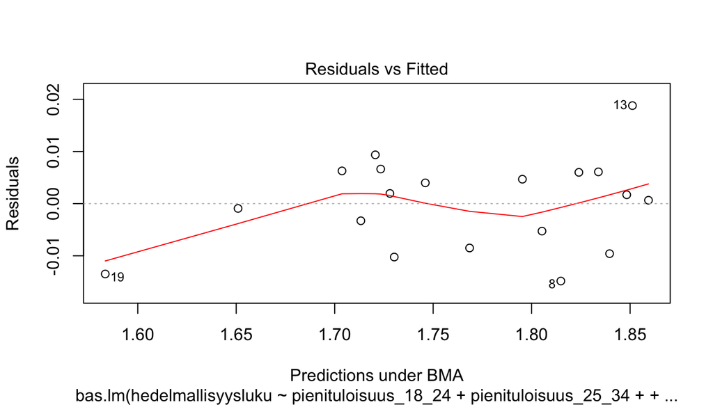

Ja lopuksi verrataan mallin sovitetta

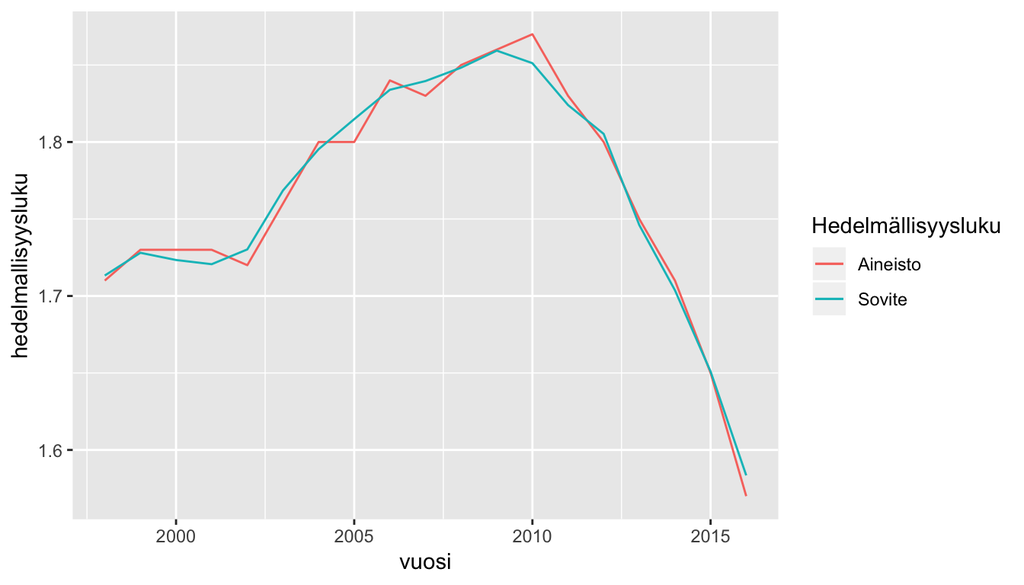

# Synnyttäjien keski-ikään vaikuttavat faktorit

```
##                                  P(B != 0 | Y) model 1 model 2 model 3
## Intercept                                1.000   1.000   1.000   1.000
## pienituloisuus_25_34                     0.321   0.000   0.000   1.000
## lapsikuolleisuus                         0.059   0.000   0.000   0.000
## tyollisyysaste_naiset_25_34_lag1         1.000   1.000   1.000   1.000
## elakemeno                                0.125   0.000   0.000   0.000
## kaupungissaasuvat                        0.606   1.000   0.000   1.000
## maaseudulla                              0.908   1.000   1.000   1.000
## sisakaupungissa                          0.999   1.000   1.000   1.000
## BF                                          NA   1.000   0.645   0.582
## PostProbs                                   NA   0.324   0.209   0.188
## R2                                          NA   0.994   0.991   0.995
## dim                                         NA   5.000   4.000   6.000
## logmarg                                     NA  47.532  47.093  46.991
```

Regressiokertoimien suuruudesta näkyy, että 25-34 -vuotiaiden naisten työllisyysasteen kasvu alentaa keski-ikää. Regressiokerroin on -0,02, jolloin 1 prosenttiyksikön kasvu työllisyysasteessa alentaisi keski-ikää 0,02 vuotta. Maaseudulla asuvien osuuden kasvu yhdellä prosenttiyksiköllä alentaisi keski-ikää 0,18 vuotta, kun taas sisemmässä kaupungissa asuvien osuuden kasvu yhdellä prosenttiyksiköllä kasvattaisi keski-ikää 0,26 vuotta. Ulommassa kaupungissa asuvien osuuden kasvu prosenttiyksiköllä alentaisi synnyttäneiden keski-ikää 0,11 vuotta.

```
##
##  Marginal Posterior Summaries of Coefficients:
##
##  Using  BMA
##
##  Based on the top  128 models
##                                   post mean  post SD    post p(B != 0)
## Intercept                         29.951947   0.007263   1.000000
## pienituloisuus_25_34              -0.007342   0.012013   0.321091
## lapsikuolleisuus                  -0.033297  11.434603   0.059381
## tyollisyysaste_naiset_25_34_lag1  -0.020996   0.002193   0.999998
## elakemeno                          0.001773   0.005979   0.124673
## kaupungissaasuvat                 -0.106313   0.110908   0.605654
## maaseudulla                       -0.177006   0.120224   0.907766
## sisakaupungissa                    0.258021   0.061956   0.999089
```

Tarkastetaan vielä, millaisia residuaaleja jää selittämättä mallilla. Kuvion mukaan residuaalit käyttäytyvät hyvin.

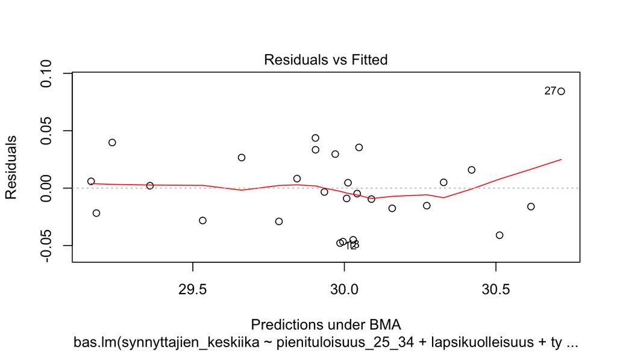

Ja lopuksi verrataan mallin sovitetta

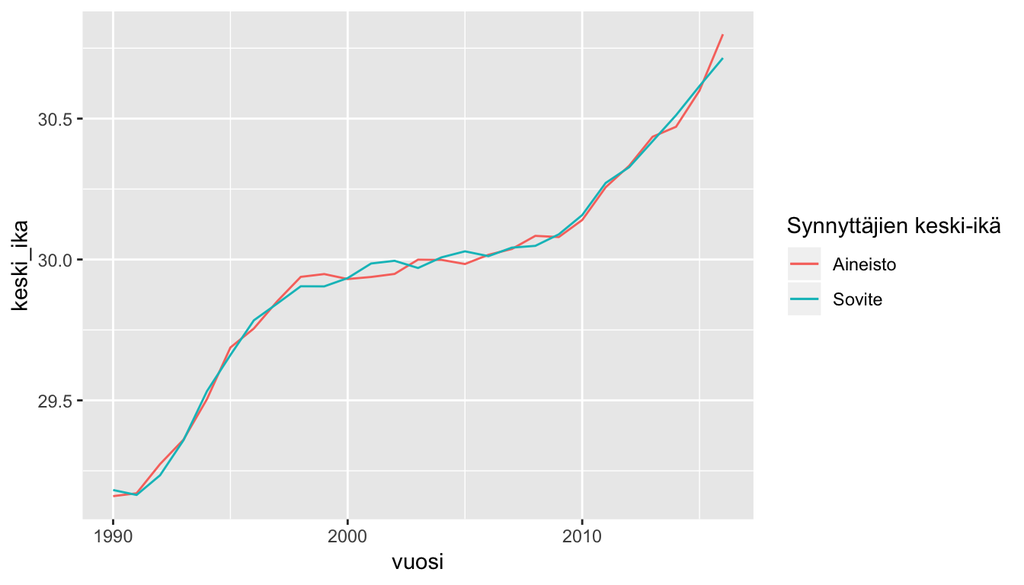

## Työsuhteen tyypin vaikutus syntyvyyteen

```r
syntyvyys_reg = bas.lm(hedelmallisyysluku ~pienituloisuus_0_17 + pienituloisuus_18_24 + pienituloisuus_25_34 + pienituloisuus_35_49 + synnyttajien_keskiika + jatkuvakokoaika_miehet + jatkuvaosaaika_miehet + maaraaikakoko_miehet + maaraaikaosa_miehet + jatkuvakokoaika_naiset + jatkuvaosaaika_naiset + maaraaikakoko_naiset + maaraaikaosa_naiset+ kaupungissaasuvat + maaseudulla + sisakaupungissa, data = tyyppiaineisto,
prior = "ZS-null", modelprior = uniform())
```

Verrattuna aiempiin tuloksiin, näkyvät samat tekijät vaikuttavan voimakkaimmin hedelmällisyyslukuun. Työsuhteen tyyppi ei näytä vaikuttavan. Tulokset vielä numeroina

```
##                        P(B != 0 | Y) model 1 model 2 model 3
## Intercept                      1.000   1.000   1.000   1.000
## pienituloisuus_0_17            0.306   0.000   0.000   0.000
## pienituloisuus_18_24           0.147   0.000   0.000   0.000
## pienituloisuus_25_34           0.379   0.000   0.000   0.000
## pienituloisuus_35_49           0.156   0.000   0.000   0.000
## synnyttajien_keskiika          0.776   1.000   1.000   1.000
## jatkuvakokoaika_miehet         0.162   0.000   0.000   0.000
## jatkuvaosaaika_miehet          0.200   0.000   0.000   0.000
## maaraaikakoko_miehet           0.159   0.000   0.000   0.000
## maaraaikaosa_miehet            0.179   0.000   0.000   0.000
## jatkuvakokoaika_naiset         0.187   0.000   0.000   0.000
## jatkuvaosaaika_naiset          0.333   0.000   1.000   0.000
## maaraaikakoko_naiset           0.166   0.000   0.000   0.000
## maaraaikaosa_naiset            0.346   0.000   0.000   1.000
## kaupungissaasuvat              0.543   0.000   0.000   0.000
## maaseudulla                    0.557   1.000   1.000   1.000
## sisakaupungissa                0.990   1.000   1.000   1.000
## BF                                NA   1.000   0.347   0.328
## PostProbs                         NA   0.045   0.016   0.015
## R2                                NA   0.959   0.965   0.965
## dim                               NA   4.000   5.000   5.000
## logmarg                           NA  19.957  18.899  18.842
```

Kolmella faktorilla, sisemmässä kaupungissa ja maaseudulla asuvien osuudet sekä synnyttäjien keski-ikä, selittävät tässä aineistossa noin 96 % varianssista. Työsuhteiden tyypin merkitys on selvästi näitä vähäisempi. Regressiokerrointen etumerkit kertovat, että naisten jatkuvien osa- ja kokoaikaisten työsuhteiden osuuden kasvu lievästi kasvattaa hedelmällisyyslukua ja naisten määräaikaiset työsuhteiden osuuden kasvu saattaa hienoisesti alentaa hedelmällisyyslukua. Näillä tekijöillä ei kuitenkaan ole juurikaan selitysvoimaa, eivätkä ne selitä viime vuosien hedelmällisyysluvun laskua.

```
##
##  Marginal Posterior Summaries of Coefficients:
##
##  Using  BMA
##
##  Based on the top  65536 models
##                         post mean   post SD     post p(B != 0)
## Intercept                1.764e+00   3.729e-03   1.000e+00
## pienituloisuus_0_17     -2.358e-03   5.122e-03   3.058e-01
## pienituloisuus_18_24    -9.147e-05   1.303e-03   1.472e-01
## pienituloisuus_25_34     4.445e-03   7.588e-03   3.792e-01
## pienituloisuus_35_49     9.675e-04   4.784e-03   1.564e-01
## synnyttajien_keskiika   -2.594e-01   1.791e-01   7.755e-01
## jatkuvakokoaika_miehet  -6.561e-05   7.016e-03   1.619e-01
## jatkuvaosaaika_miehet    4.420e-03   1.506e-02   1.998e-01
## maaraaikakoko_miehet    -2.447e-04   7.788e-03   1.589e-01
## maaraaikaosa_miehet     -4.152e-03   2.195e-02   1.794e-01
## jatkuvakokoaika_naiset   6.656e-04   9.397e-03   1.874e-01
## jatkuvaosaaika_naiset    6.561e-03   1.336e-02   3.333e-01
## maaraaikakoko_naiset    -1.575e-03   1.237e-02   1.662e-01
## maaraaikaosa_naiset     -1.812e-02   3.177e-02   3.463e-01
## kaupungissaasuvat        5.474e-02   6.077e-02   5.434e-01
## maaseudulla             -5.344e-02   6.120e-02   5.572e-01
## sisakaupungissa         -2.594e-01   8.587e-02   9.899e-01
```

Tarkastetaan vielä, millaisia residuaaleja jää selittämättä mallilla. Numeroidut residuaalit ovat outliereita. Selvästi viime vuosien hedelmällisyysluvun lasku jää osin selittämättä myös tällä mallilla.

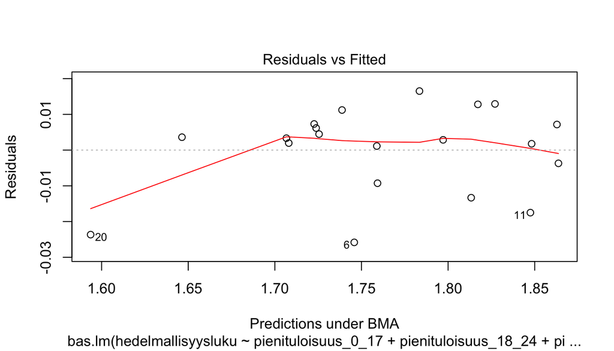

Ja lopuksi verrataan mallin sovitetta

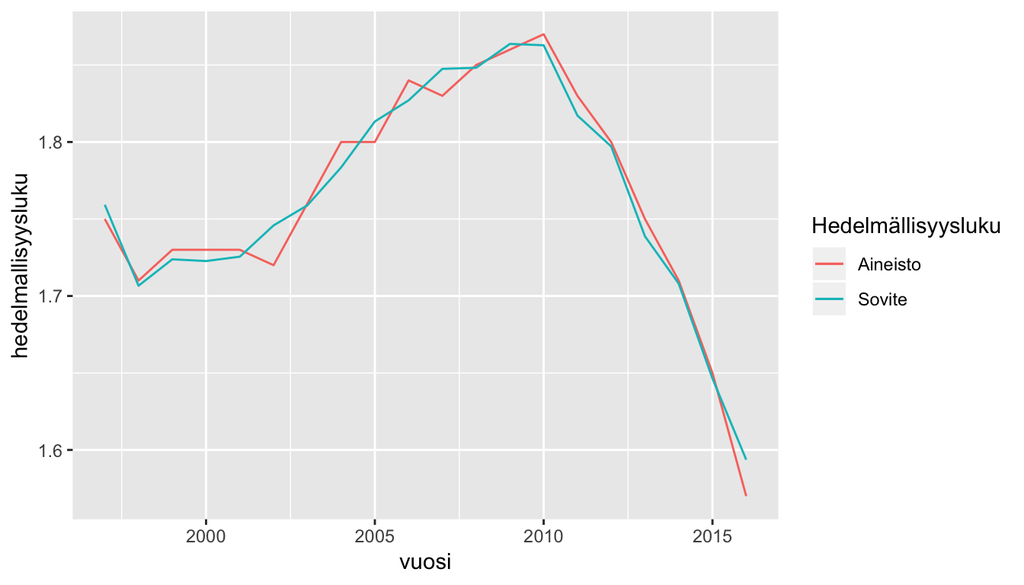

## Syntyvyyden laskun syyt

Vaikka tällä tutkimuksella ei pääse kiinni syntyvyyden laskun kausaalisiin syihin, näkyy tuloksista selvästi, että syntyvyyden laskua ajaa kaksi erilaista tekijää: hedelmällisyysluvun lasku ja synnytysikäisten naisten lukumäärän lasku. Vaikeampaa on yrittää selittää, mistä hedelmällisyysluvun lasku johtuu.

Yksi tässäkin tutkimuksessa selvästi esille tullut tekijä hedelmällisyysluvun laskulle on synnyttäneiden keski-iän nousu. Se kertoo selvästi siitä, että 20-24 -vuotiaat naiset saavat lapsia selvästi aiempaa vähemmän, samoin 25-29 -vuotiaat. Tämä saattaa johtua asenne- tai preferenssimuutoksesta, mutta myös sisäkaupungissa asuvien osuuden kasvu ja 25-34 -vuotiaiden naisten työllisyysaste kytkeytyivät tässä tutkimuksessa synnyttäneiden keski-iän nousuun.

Tilastokeskuksen tiedoista tiedetään, että kaupungeissa syntyvyys on alempaa kuin muussa maassa: “Vastaavasti matalin syntyvyys oli jaksolla 2013–2017 Helsingissä, jossa kokonaishedelmällisyysluku oli 1,27. Turussa luku oli 1,29 ja Tampereella 1,34. Myös kaikkien kuntien vertailussa viimeksi mainittujen kaupunkien syntyvyys oli matalimpien joukossa.” (Tilastokeskus, väestörakenne 2018).

Regressiokerrointen mukaan sisemmässä kaupungissa asuvien osuuden kasvu alentaa syntyvyyttä ja lykkää lasten hankintaa. Toisaalta ulommassa kaupungissa (samoin kuin maaseudulla) asuvien osuuden kasvu näyttäisi lisäävän syntyvyyttä ja vähentävän lastenhankinnan lykkäämistä. Tulokset ovat intuition mukaisia, koska sisemmissä kaupungeissa erityisesti lapsiperheille sopivien asuntojen hintataso on korkea, kun taas kauempana kaupunkien keskustoista hintataso on alempi. Kaupungistuminen ei siis välttämättä alenna syntyvyyttä, vaikka sisäkaupungeissa asuvien osuuden kasvu näyttää alentavan syntyvyyttä.

Hiilamo (2017) arvioi, että työttömyys kytkeytyy hedelmällisyyslukuun merkityksellisellä regressiokertoimella -0,12. Se on selvästi suurempi kuin tässä tutkimuksessa löytyneet regressiokertoimet (suuruusluokka -0,01), jotka eivät olleet kovin vahvasti kytkeytyneitä. Pienituloisuus kytkeytyi tutkimuksessa lievästi hedelmällisyysluvun laskuun, mutta sen merkitys jäi muita tekijöitä vähäisemmäksi.

Suurin osa lapsiperheistä on edelleen avioperheitä. Avioituvuus erityisesti 30-34-vuotiailla kytkeytyy selvästi syntyneiden lasten määrään. Ainakin aiemmin on argumentoitu, että verrattuna avoliittoihin, avioliitoissa syntyy enemmän lapsia. Kyse voi olla myös valinnasta, mutta osaltaan avioituvuuden aleneminen kertoo asenne- tai preferenssimuutoksesta.

Tässä tutkimuksessa aineisto koostui pienestä määrästä havaintoja. Tästä syystä tuloksiin on syytä suhtautua varovaisuudella, vaikka usealle löydetylle tekijälle on selkeä selitys.

## Johtopäätökset

Syntyvyyden laskua selittää muutokset synnytysikäisten naisten lukumäärässä ja hedelmällisyysluvussa. Synnytysikäisten naisten lukumäärä muuttuu hitaasti, mutta hedelmällisyysluku on laskenut nopeasti vuoden 2010 jälkeen. Hedelmällisyysluvun muutosten selittäminen onnistuu tarkastelluilla malleilla vaillinaisesti, mutta avioituvuudella ja kaupungistumisella sekä lasten hankinnan lykkäämisellä vaikuttaisi olevan kytkentä hedelmällisyysluvun laskuun. Sitä vastoin tarkastellussa aineistossa eläkemenolla, alle 1-vuotiaiden kuolleisuuden laskulla tai työsuhdetyyppien muutoksella ei näyttänyt olevan juurikaan kytkentää hedelmällisyyslukuun.

# Viittaukset

Becker, G.S., Barro, R.J., Reformulation of the economic theory of fertility, The quarterly journal of economics, 1988

Boldrin, M., De Nardi, M., Jones, L.E. Fertility and social security, Journal of Demographic Economics 81, 261-299, https://doi.org/10.1017/dem.2014.14, 2015

Doepke, M., Child mortality and fertility decline: Does the Barro-Becker model fit the facts?

Hiilamo, H. T., Fertility Response to Economic Recessions in Finland 1991–2015 Finnish Yearbook of Population Research 52, 15-28 . DOI: 10.23979/fypr.65254, 2017

Kohler, H.-P., Kohler, I., Fertility Decline in Russia in the Early and Mid 1990s: The Role of Economic Uncertainty and Labour Market Crises, European Journal of Population 18, 233-262, https://doi.org/10.1023/A:1019701812709, 2002.

Martine, G., Alves, J.E., Cavenaghi, S., Urbanization and fertility decline: Cashing in on structural change, IIED Working paper, 2013

Miettinen, A., Miksi syntyvyys laskee? Suomalaisten lastensaantiin liittyviä toiveita ja odotuksia. Perhebarometri 2015. Väestöliitto, 2015.

Miettinen, A., Jalovaara, M. Stable employment – more babies? Life stage and educational differences in the effects of labour market attachment on first birth among Finnish men and women. Working Papers on Social and Economic Issues 15/2016, Turku Center for Welfare Research, 2016

Tikanmäki, H., Huomisen aikuiset syntyvät nyt, Eläketurvakeskuksen blogi https://www.etk.fi/blogit/huomisen-aikuiset-syntyvat-nyt/, 2017

# Liite: Aika-sarjojen kuvaukset

*syntyneet* Syntyneiden lasten lukumäärä. Lähde: Tilastokeskus

*hedelmallisyysluku* “Kokonaishedelmällisyysluku saadaan laskemalla yhteen yhdelle ikävuodelle lasketut hedelmällisyysluvut. Näin saatu luku tarkoittaa laskennallista lasten määrää, jonka nainen synnyttää kyseisen vuoden hedelmällisyyden pysyessä voimassa naisen koko hedelmällisen kauden edellyttäen, ettei hän kuole ennen tämän kauden päättymistä.” Lähde: Tilastokeskus, Väestörakenne-tilasto

*pienituloisuus_0_17, pienituloisuus_18_24, pienituloisuus_25_34, pienituloisuus_35_49, pienituloisuus_50_64* “Pienituloisuusaste: Pienituloisten osuus kyseisessä väestöryhmässä. Pienituloisia henkilöitä: Pienituloisia henkilöitä kyseisessä väestöryhmässä. Pienituloisten mediaanitulo: Pienituloisten ekvivalentit mediaanitulot kyseisessä väestöryhmässä. Köyhyysvaje: Pienituloisten tulomediaanin ja koko väestön pienituloisuusrajan erotus prosentteina rajasta. Ekvivalenttitulo: Kotitalouden käytettävissä olevat rahatulot kulutusyksikköä kohden vuodessa. Kulutusyksikkö: Modifioitu OECD-asteikko (1.0 - 0.5 - 0.3). Pienituloisuusrajat lasketaan vuosittain kaikkien kotitalouksien ekvivalenttitulon mediaanin perusteella. Julkaisuissa käytetty virallinen pienituloisuusraja on 60 % mediaanitulosta ja tulokäsite käytettävissä olevat rahatulot.Euromääräiset tiedot on esitetty vuoden 2016 rahassa.” Lähde: Tilastokeskus, Tulonjakotilasto

*lapsikuolleisuus* Alle 1-vuotiaana kuolleiden osuus elävänä syntyneistä. Lähde: Human mortality database

*tyollisyysaste_miehet_15_24_lag1, tyollisyysaste_naiset_25_34_lag1, tyollisyysaste_miehet_35_44_lag1, tyollisyysaste_naiset_15_24_lag1, tyollisyysaste_miehet_25_34_lag1, tyollisyysaste_naiset_45_44_lag1* Yhden vuoden viivästetty 10-vuotisikäluokittainen työllisyysaste miehille ja naisille. Lähde: Tilastokeskus

*synnyttajien_keskiika* Laskettu synnyttäneiden äitien ikien keskiarvona. Lähde: Tilastokeskus

*avioituvuus_naiset_25_29, avioituvuus_naiset_30_34* Naisten solmittujen avioliittojen lukumäärä suhteessa samanikäisten naisten lukumäärään. Lähde: Tilastokeskus

*elakemeno* Kokonaiseläkemeno Suomessa prosentteina BKT:stä Lähde: Eläketurvakeskus

*kaupungissaasuvat, maaseudulla, sisakaupungissa* Kaupungeissaasuvien osuus väestöstä, maaseudulla asuvien osuus väestöstä ja Lähde: Tilastokeskus

*jatkuvakokoaika_miehet, jatkuvaosaaika_miehet, maaraaikakoko_miehet, maaraaikaosa_miehet, jatkuvakokoaika_naiset, jatkuvaosaaika_naiset, maaraaikakoko_naiset, maaraaikaosa_naiset* Lähde: Tilastokeskus, työvoimatutkimus

*naisten_lkm_15_19, naisten_lkm_20_24, naisten_lkm_25_29, naisten_lkm_30_34,naisten_lkm_35_39, naisten_lkm_40_45, naisten_lkm_45_49* Synnytysikäiset naiset 5-vuotisikäluokittain Lähde: Tilastokeskus

*miesten_tyottomyysaste_15_24_lag1, naisten_tyottomyysaste_15_24_lag1, miesten_tyottomyysaste_25_34_lag1, naisten_tyottomyysaste_25_34_lag1, miesten_tyottomyysaste_35_44_lag1, naisten_tyottomyysaste_35_44_lag1* Yhden vuoden viivästetty 10-vuotisikäluokittainen työttömyysaste miehille ja naisille Lähde: Tilastokeskus

# Liite: Kaupunkialueet

**Sisempi kaupunkialue** Sisempi kaupunkialue kuvaa kaupunkien tiivistä ja yhtenäistä tehokkaasti rakennettua aluetta. Sisemmällä kaupunkialueella lähiympäristön vallitseva aluetehokkuus on vähintään 0,1, joka vastaa tiivistä pientaloaluetta. Sisemmästä kaupunkialueesta irrallaan sijaitsevat korkean aluetehokkuuden alueet sisällytetään ulompaan kaupunkialueeseen. Jokaisella keskustaajamalla voi olla vain yksi sisempi kaupunkialue. Poikkeuksen tästä muodostavat Helsingin kaupunkiseudulla sijaitsevat kaupungit Järvenpää ja Kerava, joille muodostetaan oma sisempi kaupunkialue. Lähde: Ympäristöministeriö

**Ulompi kaupunkialue** Ulompi kaupunkialue koostuu erillisistä lähiöistä, kaupan, teollisuuden ja toimistojen reunakaupungista sekä toisaalta kaupungin viheralueista ja alemman tehokkuuden asuinalueista, jotka kuitenkin ovat selvästi osa yhtenäistä kaupunkialuetta. Ulommalla kaupunkialueella kolmasosa lähiympäristöstä on vähintään 0,02 aluetehokkuuden aluetta. Tällä kriteerillä ulomman kaupunkialueen ulkoraja estimoi asemakaavoitetun alueen ulkorajaa ja näin suunnitellusti rakennettua yhtenäistä kaupunkialuetta. Lähde: Ympäristöministeriö